# PRA 2: Neteja, validació i anàlisi de les dades

### 2.5.2 Variables qualitatives

Fem una primera exploració visual d’aquest tipus de variable:

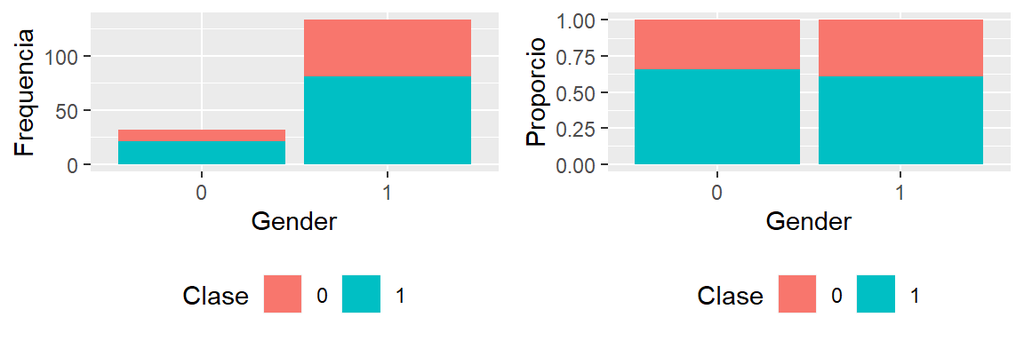

Gender

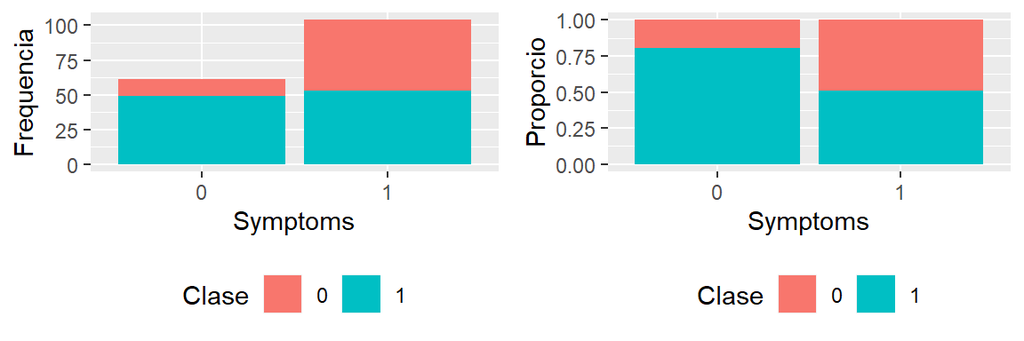

Symptoms

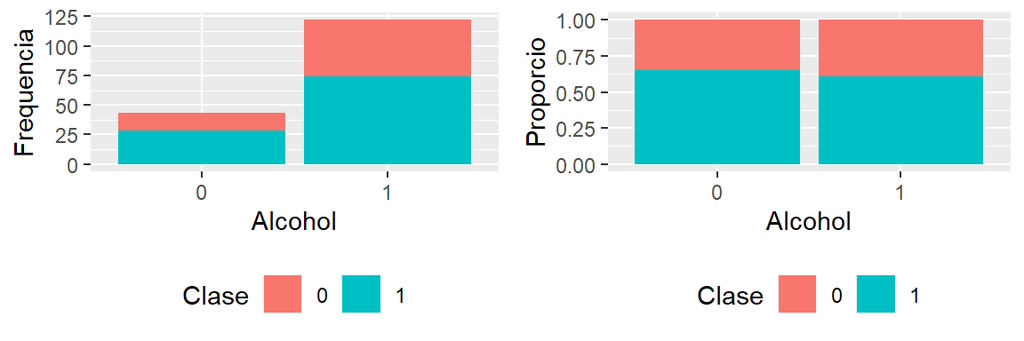

Alcohol

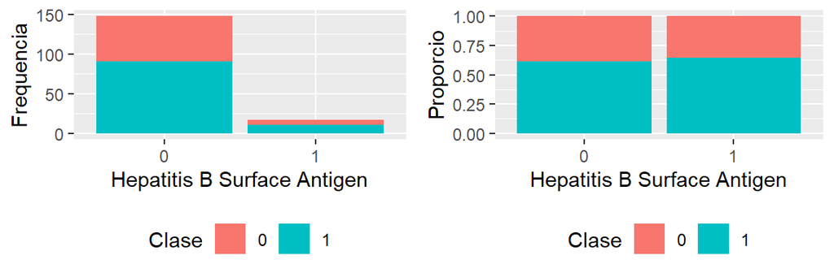

Hepatitis B Surface Antigen

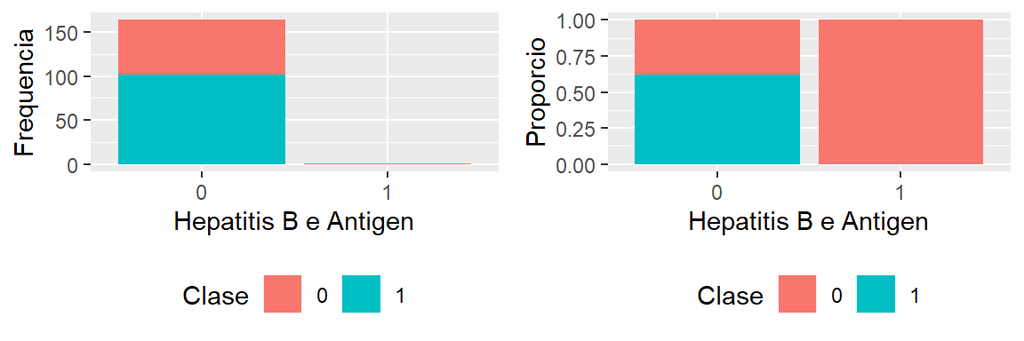

Hepatitis B e Antigen

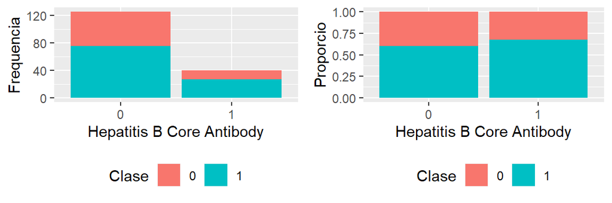

Hepatitis B Core Antibody

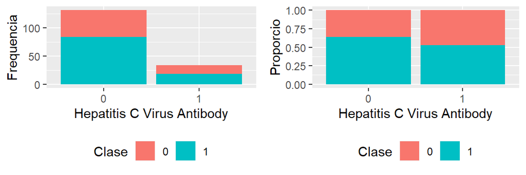

Hepatitis C Virus Antibody

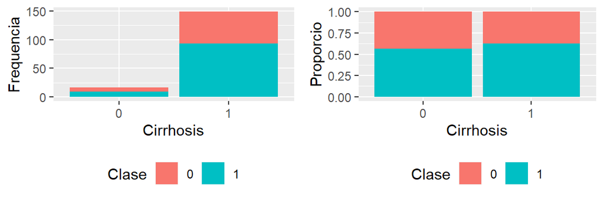

Cirrhosis

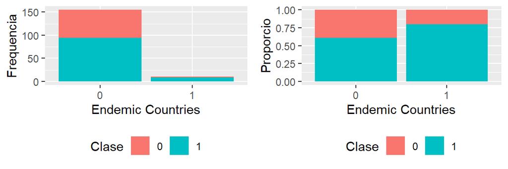

Endemic Countries

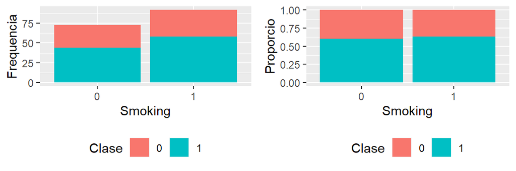

Smoking

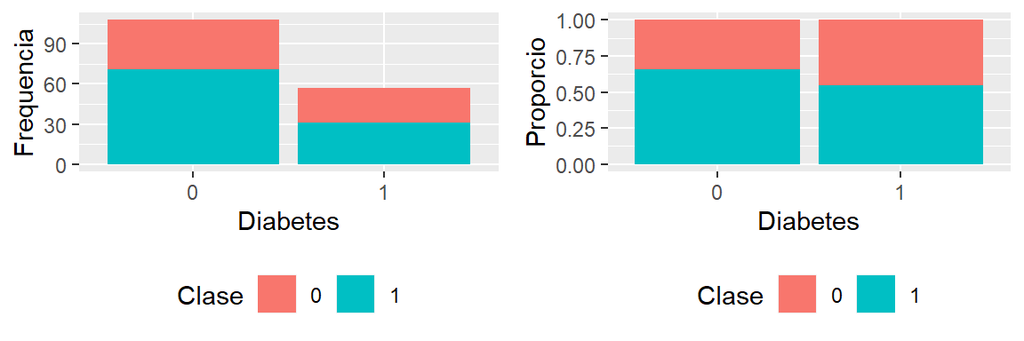

Diabetes

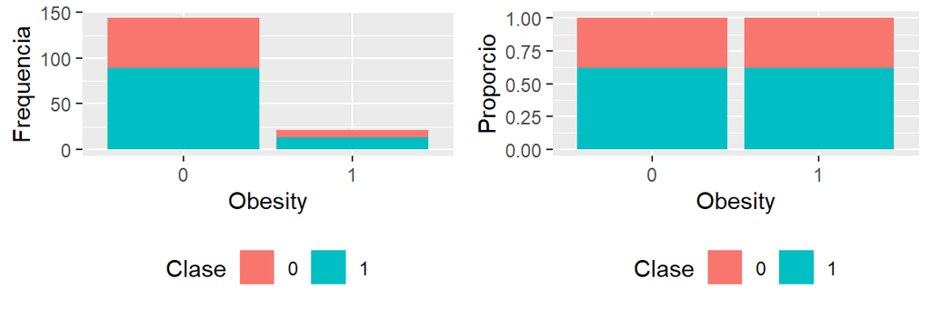

Obesity

[14 more figures not shown]

```r
# Distribució variables quantitatives
hcc_factorT<-c(1:23,27:29)
figCapsFac <- names(hcc)[hcc_factorT]

# grafic 1 - diagrama barres
# grafic 2 - diagrama barres proporció
for (i in 1:length(hcc_factorT) ) {
  data <- hcc[,c(hcc_factorT[i],ind_CA )]
  name_var <- names(data)

  a1<-data %>%
    ggplot(aes(x=data[,1],fill=`Class Attribute`))+
    geom_bar() +
    labs(fill="Clase", x = name_var[1], y = "Frequencia") +
    theme(legend.position = "bottom",
          plot.caption = element_text(hjust = 0.5))

  a2<- data %>%
    ggplot(aes(x=data[,1],fill=`Class Attribute`))+
    geom_bar(position = "fill") +
    labs(fill="Clase", x = name_var[1], y = "Proporcio") +
    theme(legend.position = "bottom",
          plot.caption = element_text(hjust = 0.5))

  grid.arrange(a1,a2, nrow= 1)
  cat('\n\n')
}
```

De les variables quantitatives podem veure que entre elles hi ha força diferència en la proporció de persones que sobreviuen segons el valor de la variable. Per exemple, per a la variable Smoking aquesta diferència no és notable, però per Ascites degree sí que ho és. És a dir, podem preveure que sí que hi haurà variables que influiran en la mortalitat d’aquests pacients i d’altres que semblen que no.

### 2.5.3 Comprobació de la normalitat i homogeneïtat de la variància

Per la comprovació de la distribució normal dels valors quantitatius farem servir la prova de normalitat d’Anderson-Darling.

```r
#Test Anderson-Darling per a la normalitat
col.names = colnames(hcc)
tNorm <- tibble()
for (i in 1:ncol(hcc)) {
  if (is.integer(hcc[,i]) | is.numeric(hcc[,i])) {
    p_val = ad.test(hcc[,i])$p.value
    tNorm <- tNorm %>% bind_rows(c("Variable" = col.names[i],"p_value" = p_val))
  }
}

#Filtrar les que no rebutgen l'hipotesis de normalitat
var_normales<- tNorm %>% filter(as.numeric(p_value)>0.05) %>% pull(Variable)
tau <- tNorm %>% filter(p_val < 0.05) %>%
  mutate_at(.vars = c("p_value"), as.numeric)
tau <- cbind(tau[1:12,],tau[13:24,])

#Correió d'ultima fila columna dreta
tau[12,3 ] <- ""
tau[12,4 ] <- 0

#Presentacio resultats
kable(x = tau, format = "latex", caption = "Variables que no segueixen una distribució normal",
      booktabs = TRUE, digits = 4, linesep = '') %>%
  kable_styling(latex_options = c("HOLD_position", "scale_down")) %>%
  row_spec(row=0, bold = TRUE)
```

Com es pot veure, hi ha moltes variables numèriques que es distancien significativament de la distribució normal, pel que es faran servir test no paramètrics (Mann–Whitney–Wilcoxon) per la comparativa amb relació a la supervivència.

Només hi ha quatre variables que no es pot assegurar que no segueixin una distribució normal. Comprovarem si aquestes mantenen una variància similar entre els grups formats per la classe amb el test de Levene.

```r
#Test Levene per homogeneïtat de la variància
tVar <- tibble()

for (i in var_normales){
  p_val = leveneTest(group=hcc$`Class Attribute`, y=hcc[,i])$`Pr(>F)`[1]
  tVar <- tVar %>% bind_rows(c("Variable" = i,"p_value" = p_val))
}

tVar <- tVar %>%mutate_at(.vars = c("p_value"), as.numeric)

#presentacio de resultats
kable(x = tVar, format = "latex", caption = "Homogeneitat de la varinça a partir del test de Levene.",
      booktabs = TRUE, digits = 4, linesep = '') %>%
  kable_styling(latex_options = c("HOLD_position")) %>%
  row_spec(row=0, bold = TRUE)
```

Com es pot veure, només dues de totes les variables quantitatives ( **Haemoglobin (g/dL)** i **log_Gamma glutamyl transferase (U/L)**) segueixen una distribució normal i no tenen diferències significatives entre les variàncies entre la població que sobreviu i la que no.

## 2.6 Proves estadístiques

### 2.6.1 Comparació entre grups de la classe

Per tal de valorar quines variables es comporten diferents entre en què sobreviuen i els que no, es realitzarà els diferents tests estadístics:

- Per les variables qualitatives es realitzarà un test chi-quadrat.
- Per les variables quantitatives, donada les seves distribucions majoritària diferent de la normalitat, es realitzarà el test no paramètric de Mann–Whitney–Wilcoxon

```r
#Test chi-quadrat per a variables qualitatives
testChi <- tibble()
for (i in hcc_factorT) {
  tau=table(hcc[,i], hcc$`Class Attribute`)
  chi=chisq.test(tau)
  testChi <- testChi %>% bind_rows(c(Variable=names(hcc[i]),p_value = chi$p.value))
}

#Filtrar les que rebutgen hipotesis nul·la
tau <- testChi %>% filter(p_value < 0.1) %>%
  mutate_at(.vars = c("p_value"), as.numeric)

#Guardar vairables significatives
varSig <- tau

#Presentacio de resultats
kable(x = tau, format = "latex", caption = "Variables categóriques amb p<0.10 entre la classe",
      booktabs = TRUE, digits = 4, linesep = '') %>%
  kable_styling(latex_options = c("HOLD_position")) %>%
  row_spec(row=0, bold = TRUE)
```

```r
#Test Mann–Whitney–Wilcoxon per a variables quantitatives
testWil <- tibble()
for (i in hcc_num) {
  wil=wilcox.test(hcc[hcc$`Class Attribute`==1,i],
                  hcc[hcc$`Class Attribute`==0,i],
                  mu = 0,paired = FALSE, conf.int = 0.95)
  testWil <- testWil %>%
    bind_rows(c(Variable=names(hcc[i]),p_value = wil$p.value))
}

#Filtrar les que rebutgen hipotesis nul·la
tau <- testWil %>% filter(p_value < 0.1) %>%
  mutate_at(.vars = c("p_value"), as.numeric)

#Guardar vairables significatives
varSig <- varSig %>% bind_rows(tau)

#Resultats en dos columnes
tau <- cbind(tau[1:6,],tau[7:12,])

#Presentacio de resultats
kable(x = tau, format = "latex", caption = "Variables numériques amb p<0.10 entre la classe",
      booktabs = TRUE, digits = 4, linesep = '') %>%
  kable_styling(latex_options = c("HOLD_position", "scale_down")) %>%
  row_spec(row=0, bold = TRUE)
```

Aquestes variables seran les que se seleccionarà per a la creació d’un model de regressió logística, però abans, valorarem les correlacions entre elles per tal de seleccionar variables que estiguin poc relacionades entre elles.

### 2.6.2 Correlació entre les variables seleccionades

Respecte a la correlació entre les variables seleccionades, veiem la seva matriu de correlacions. Donada l’existència de variables categòriques, aquestes és consideraran numèriques i usarem la correlació no paramètrica de Spearman per a la seva valoració. Prèviament es normalitzaran totes les variables quantitatives.

```r
# Correlació variables independents.
hcc_norm <- hcc
atr<-names(hcc)

#normalitzacio variables quantitatives
hcc_norm[,hcc_num]<-scale(hcc_norm[,hcc_num])

#variables quantitatives tipus numeric
hcc2<-as.data.frame(lapply(hcc_norm,as.numeric))
names(hcc2)<-atr

#correlacio Spearman + filtrar alta correlació
hcc_cor<-cor(hcc2[,varSig$Variable], method = "spearman")
col.names <- colnames(hcc_cor)
hcc_corTop <- as.tibble(hcc_cor) %>% melt()
hcc_corTop$variable2 <- col.names
hcc_corTop <- hcc_corTop %>%
  dplyr::select(variable, variable2, value) %>%
  rename(corr = value) %>%
  filter(variable != variable2) %>%
  filter(abs(corr) >= 0.8) %>%
  arrange(-corr) %>%
  group_by(corr) %>%
  mutate(Variables = paste(variable, collapse = '-')) %>%
  dplyr::select(Variables, corr) %>%
  unique()

#Presentació variables altament correlades
kable(x = hcc_corTop, format = "latex",
      caption = "Correlació entre variables, valors entre -1 i -08 o 0-8 i 1.",
      booktabs = TRUE, digits = 4, linesep = '') %>%
  kable_styling(latex_options = c("HOLD_position")) %>%
  row_spec(row=0, bold = TRUE)
```

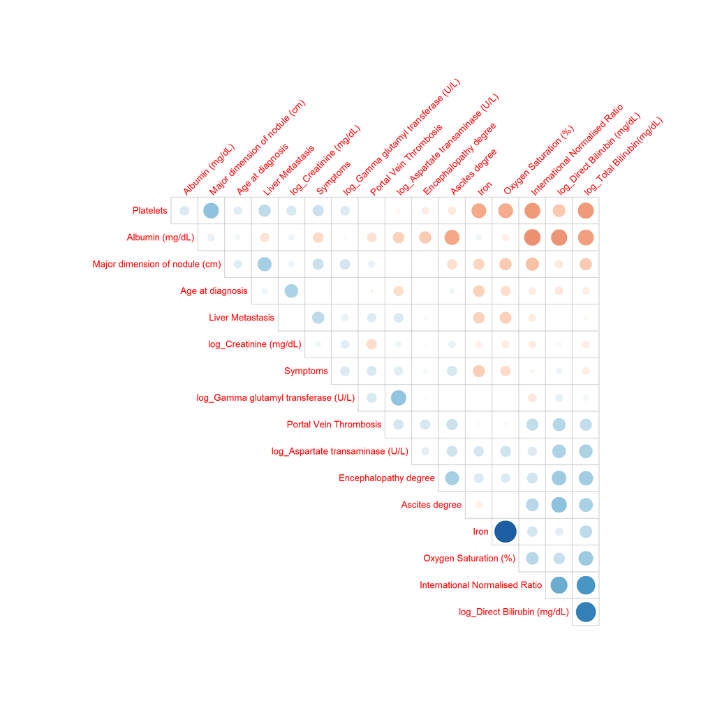

Grafica de correlacions

```r
#Grafica de totes les correlacions
corrplot(hcc_cor, cl.pos='n',tl.srt = 45,
         tl.cex = 1.25, type="upper",method = "circle",
         order="FPC", diag=FALSE)
```

Com es pot veure, només dues variables tenen una molt alta correlació ( **Iron** i **Oxygen Saturation (%)**). De les dues, seleccionarem **Iron** que és la que presenta una menor probabilitat de significació.

### 2.6.3 Creació de noves variables

Hi ha un valor conegut per a valorar la probabilitat de mort al cap de tres mesos de pacients amb hepatopatia que depèn de la creatinina, la bilirubina total i de l’INR, amb un valor calculat denominat MELD. Aquest valor és una estimació de probabilitat de fallida hepàtica. A majors valors major probabilitat de mort. Aquest valor està validat pels tres mesos, no per a l’any, com és el nostre cas.

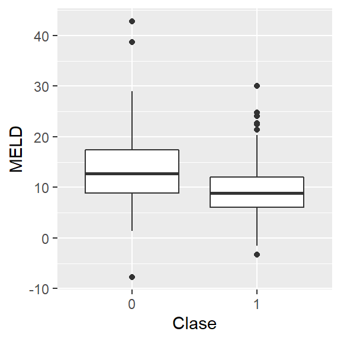

Box plot MELD

```r
# MELD calculat vs clase
hcc <- hcc %>%
  mutate(MELD = 3.78*`log_Total Bilirubin(mg/dL)`+
           11.2*log(`International Normalised Ratio`)+
           9.57*hcc$`log_Creatinine (mg/dL)`+
           6.43 )

#Boxplot per veure la distribució repsecte clase
hcc %>%
  ggplot(aes(x=`Class Attribute`,y=MELD)) +
  geom_boxplot() +
  labs(x = "Clase",  y = "MELD")
```

```r
#Test Mann–Whitney–Wilcoxon
x = hcc %>% filter(`Class Attribute`==1) %>% pull(MELD)
y = hcc %>% filter(`Class Attribute`==0) %>% pull(MELD)
wilcox.test(x,y, mu = 0,paired = FALSE, conf.int = 0.95)
```

```
##
##  Wilcoxon rank sum test with continuity correction
##
## data:  x and y
## W = 2139.5, p-value = 0.0003196
## alternative hypothesis: true location shift is not equal to 0
## 95 percent confidence interval:
##  -5.697309 -1.735361
## sample estimates:
## difference in location
##              -3.697976
```

Es pot veure que els valors de MELD són significativament diferents entre el grup de pacients que sobreviuen i els que no. Amb aquesta combinació lineal agrupem en una única variable la bilirubina total, l’INR i la creatinina.

## 2.7 Resolució del problema, model amb regressió logística

Amb les variables seleccionades, es crearà un model de regressió logística per tal de predir la supervivència a l’any del diagnòstic d’HCC. La variable ordinal es considerarà numèrica.

```r
#Model logit
varElim <- c("Oxygen Saturation (%)","log_Total Bilirubin(mg/dL)",
             "International Normalised Ratio","log_Creatinine (mg/dL)")

#Variables seleccionades
var_selecc<- setdiff(varSig$Variable, varElim)

#Afegir les que falten
hcc_sel <- hcc[c(var_selecc, "MELD", "Class Attribute")] %>%
  mutate_at(vars("Ascites degree","Encephalopathy degree"), as.numeric)

#Model logistic
modelo <- glm(`Class Attribute` ~ ., data = hcc_sel, family = "binomial")
summary(modelo)
```

```
##
## Call:
## glm(formula = `Class Attribute` ~ ., family = "binomial", data = hcc_sel)
##
## Deviance Residuals:
##     Min       1Q   Median       3Q      Max
## -2.3256  -0.7560   0.3625   0.7034   2.1115
##
## Coefficients:
##                                          Estimate Std. Error z value
## (Intercept)                             4.338e+00  2.493e+00   1.740
## Symptoms1                              -7.260e-01  4.690e-01  -1.548
## `Portal Vein Thrombosis`1              -4.829e-01  5.045e-01  -0.957
## `Liver Metastasis`1                    -3.996e-01  5.269e-01  -0.758
## `Encephalopathy degree`                -7.901e-02  5.591e-01  -0.141
## `Ascites degree`                       -1.814e-01  3.164e-01  -0.574
## `Age at diagnosis`                     -1.757e-02  1.667e-02  -1.054
## Platelets                               4.129e-07  2.260e-06   0.183
## `Albumin (mg/dL)`                       4.739e-01  3.490e-01   1.358
## `log_Aspartate transaminase (U/L)`     -5.985e-01  3.439e-01  -1.740
## `log_Gamma glutamyl transferase (U/L)` -1.090e-01  2.603e-01  -0.419
## `Major dimension of nodule (cm)`       -1.021e-01  4.602e-02  -2.219
## `log_Direct Bilirubin (mg/dL)`         -3.561e-01  2.925e-01  -1.217
## Iron                                    1.533e-02  5.152e-03   2.976
## MELD                                   -7.455e-02  4.042e-02  -1.844
##                                        Pr(>|z|)
## (Intercept)                             0.08181 .
## Symptoms1                               0.12169
## `Portal Vein Thrombosis`1               0.33840
## `Liver Metastasis`1                     0.44821
## `Encephalopathy degree`                 0.88761
## `Ascites degree`                        0.56631
## `Age at diagnosis`                      0.29193
## Platelets                               0.85502
## `Albumin (mg/dL)`                       0.17459
## `log_Aspartate transaminase (U/L)`      0.08182 .
## `log_Gamma glutamyl transferase (U/L)`  0.67547
## `Major dimension of nodule (cm)`        0.02647 *
## `log_Direct Bilirubin (mg/dL)`          0.22342
## Iron                                    0.00292 **
## MELD                                    0.06514 .
## ---
## Signif. codes:  0 '***' 0.001 '**' 0.01 '*' 0.05 '.' 0.1 ' ' 1
##
## (Dispersion parameter for binomial family taken to be 1)
##
##     Null deviance: 219.43  on 164  degrees of freedom
## Residual deviance: 152.68  on 150  degrees of freedom
## AIC: 182.68
##
## Number of Fisher Scoring iterations: 5
```

```r
#Prediccions de resultats + matriu de confusió
pred1 <- ifelse(test = modelo$fitted.values > 0.50, yes = 1, no = 0)
matConf <- table(hcc_sel$`Class Attribute`, pred1,
                 dnn = c("observacions", "prediccions"))

kable(x = matConf, format = "latex",
      caption = "Matriu de confusió model general, prediccions per columna, observacions per files",
      booktabs = TRUE, linesep = '') %>%
  kable_styling(latex_options = c("HOLD_position")) %>%
  row_spec(row=0, bold = TRUE)
```

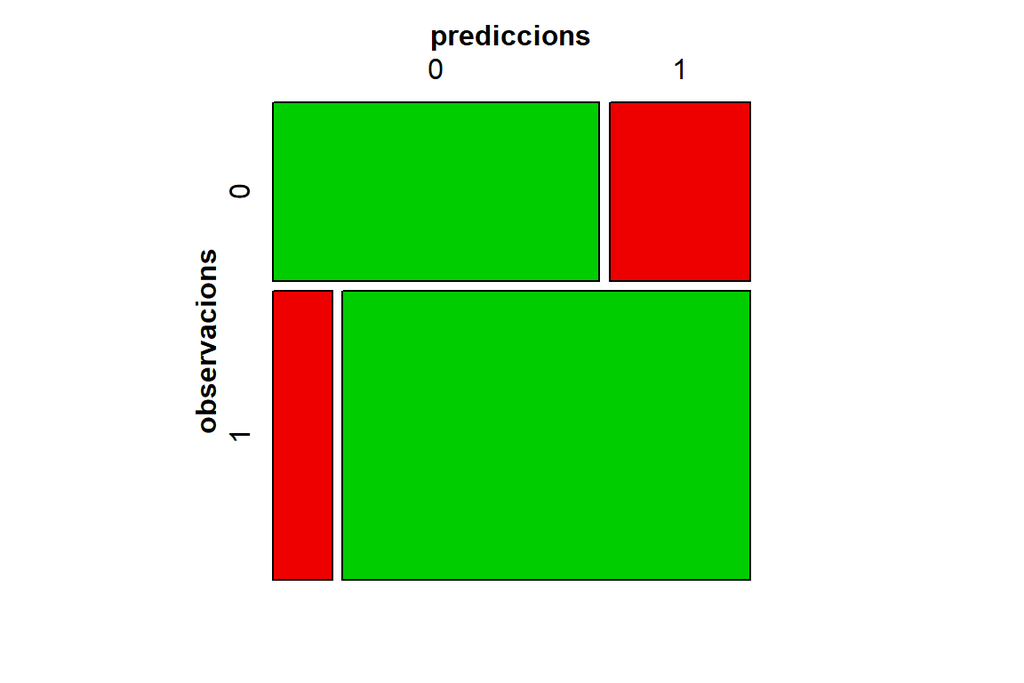

Matriu confusio model general

```r
#Grafic de matriu de confusió
mosaic(matConf, shade = T, colorize = T,
       gp = gpar(fill = matrix(c("green3", "red2", "red2", "green3"), 2, 2)))
```

```r
#Èxit del model
presPred <- 100*(matConf[1]+matConf[4])/nrow(hcc_sel)
```

Aquest model amb totes les variables té un 80.6% d’èxit en la predicció de la supervivència del pacient. Pintem la corba ROC i auc del model:

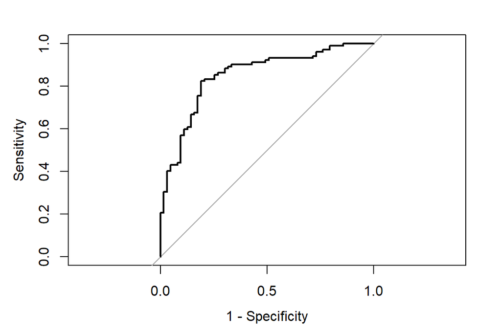

Corba ROC model general

```r
#Predir els valors del model
prob <- predict(modelo,type = "response")
hcc$prob <- prob

#Pintar corba ROC, legacy.axes = TRUE per tal de pintar 1- Specifity, si no pinta Specifity.
plot.roc(`Class Attribute` ~ prob,data = hcc,legacy.axes = TRUE)
```

```r
#Area sota la corba
auc(roc(`Class Attribute` ~ prob,data = hcc))
```

```
## Area under the curve: 0.8511
```

Podem veure que tenen valors molts bons.

El nostre objectiu és construir un segon model de regressió logística fent servir menys variables, evitant així haver de conèixer moltes variables d’un pacient i amb unes miques menys poder també fer la predicció. Per tal de seleccionar un model amb menys atributs sense disminuir excessivament l’error del model, es realitzarà un estudi iteratiu eliminant a cada pas la variable menys significativa (“backward”).

```r
#Model logit mètode backward
modback <- stepAIC(modelo, trace=FALSE, direction="backward")
summary(modback)
```

```
##
## Call:
## glm(formula = `Class Attribute` ~ Symptoms + `Albumin (mg/dL)` +
##     `log_Aspartate transaminase (U/L)` + `Major dimension of nodule (cm)` +
##     `log_Direct Bilirubin (mg/dL)` + Iron + MELD, family = "binomial",
##     data = hcc_sel)
##
## Deviance Residuals:
##     Min       1Q   Median       3Q      Max
## -2.3839  -0.7748   0.3944   0.7448   2.0297
##
## Coefficients:
##                                     Estimate Std. Error z value Pr(>|z|)
## (Intercept)                         2.476225   1.908340   1.298 0.194431
## Symptoms1                          -0.870723   0.457772  -1.902 0.057159
## `Albumin (mg/dL)`                   0.514117   0.331922   1.549 0.121404
## `log_Aspartate transaminase (U/L)` -0.639796   0.303998  -2.105 0.035325
## `Major dimension of nodule (cm)`   -0.121036   0.041407  -2.923 0.003466
## `log_Direct Bilirubin (mg/dL)`     -0.408255   0.271661  -1.503 0.132887
## Iron                                0.016260   0.004648   3.499 0.000468
## MELD                               -0.090825   0.036977  -2.456 0.014040
##
## (Intercept)
## Symptoms1                          .
## `Albumin (mg/dL)`
## `log_Aspartate transaminase (U/L)` *
## `Major dimension of nodule (cm)`   **
## `log_Direct Bilirubin (mg/dL)`
## Iron                               ***
## MELD                               *
## ---
## Signif. codes:  0 '***' 0.001 '**' 0.01 '*' 0.05 '.' 0.1 ' ' 1
##
## (Dispersion parameter for binomial family taken to be 1)
##
##     Null deviance: 219.43  on 164  degrees of freedom
## Residual deviance: 156.83  on 157  degrees of freedom
## AIC: 172.83
##
## Number of Fisher Scoring iterations: 5
```

Podem veure com aquest model selecciona fins a 7 variables. Podem veure com l’AIC és menor en aquest model. Calculem la matriu de confusió i el percentatge d’encert en la predicció:

```r
#prediccio resultat + matriu de confusió
pred2 <- ifelse(test = modback$fitted.values > 0.50, yes = 1, no = 0)
matConf<- table(hcc_sel$`Class Attribute`, pred2,
                dnn = c("observacions", "prediccions"))

kable(x = matConf, format = "latex",
      caption = "Matriu de confusió model reduit, prediccions per columna, observacions per files",
      booktabs = TRUE, linesep = '') %>%
  kable_styling(latex_options = c("HOLD_position")) %>%
  row_spec(row=0, bold = TRUE)
```

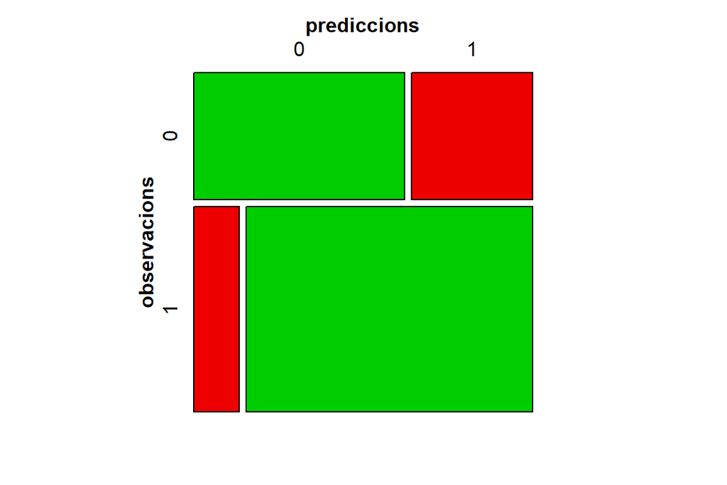

Matriu confusio model reduit

```r
#grafica matriu de confusió
mosaic(matConf, shade = T, colorize = T,
       gp = gpar(fill = matrix(c("green3", "red2", "red2", "green3"), 2, 2)))
```

```r
#Èxit del model
presPred2 <- 100*(matConf[1]+matConf[4])/nrow(hcc_sel)
```

El model generat te només 7 variables i obté un 77.6% de precisió en les prediccions. Pel que fa a l’especifitat i sensibilitat del model:

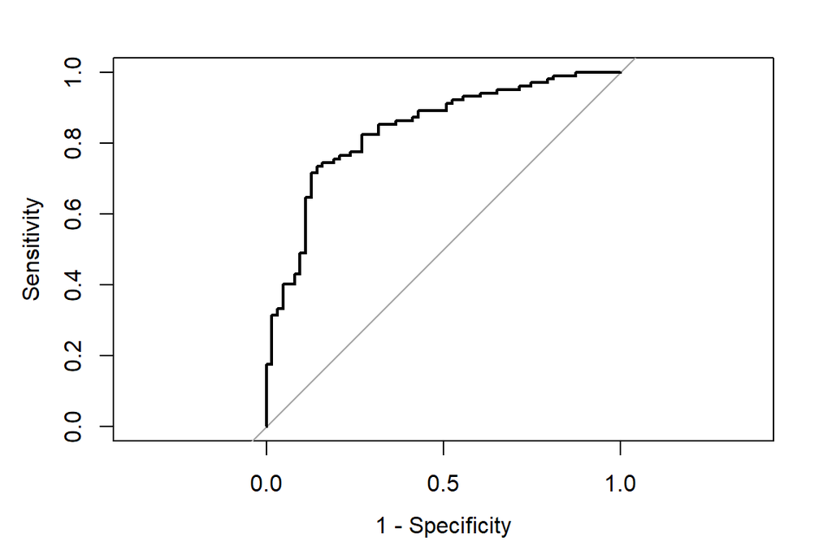

Corba ROC model reduit

```r
#predicció variables
prob2 <- predict(modback,type = "response")
hcc$prob2 <- prob2

#Pintar corba ROC, legacy.axes = TRUE per tal de pintar 1- Specifity, si no pinta Specifity.
plot.roc(`Class Attribute` ~ prob2,data = hcc,legacy.axes = TRUE)
```

```r
#Area sota la corba
auc(roc(`Class Attribute` ~ prob2,data = hcc))
```

```
## Area under the curve: 0.8392
```

Podem veure com el valor de AUC és també una mica pitjor.

Si poguéssim tenir totes les dades possibles, ens quedaríem amb el primer model, ja que té una millor predicció de les dades i un valor AUC més elevat. Tanmateix, reduint quasi a la meitat el nombre de variables podem obtenir uns resultats molt bons.

Per tant, hem construït un model logístic, que ens determina la supervivència o no d’un pacient d’acord amb uns indicadors mèdics amb un 80% aproximadament d’èxit. És un molt bon punt per anar refinant el model i millorar el seu ajust.

# 3 Conclusions

Aquest treball s’ha realitzat sobre dades reals sense processar i, com hem pogut comprovar, és necessari un primer pas de neteja per a poder crear models útils. Les dades en brut tenen valors desconeguts, erronis, i extrems els quals s’han de tractar. En el nostre cas, només 8 dels 165 pacients registrats i només 5 dels 49 atributs disposaven de totes les dades. Eliminar atributs o pacients amb valors desconeguts condicionaria una pèrdua molt important de dades, per al que vam decidir corregir els valor desconeguts amb diferents tècniques d’imputació de valors com són kNN i l’assignació de la mitjana. També hem pogut comprovar que conèixer l’àmbit de les dades fa que sigui possible detectar i corregir algunes de les dades introduïdes erròniament.

Amb el contrast d’hipòtesi hem pogut seleccionar les variables que més influeixen en la supervivència d’aquests pacients i amb l’estudi de correlacions entre aquests atributs eliminar els que tenen alta correlació, per finalment crear models de regressió logística per intentar predir la supervivència. Inclús seleccionant un model de només 7 atributs s’aconsegueix una alta precisió en les prediccions.

# 4 Taula de contribucions

La contribució en aquesta pràctia ha sigut:

```r
tauContribucions <- tibble(Contribucions = c("Investigació previa",
                                             "Redacció de les respostes",
                                             "Desenvolupament del codi"),
                           Firma = c("A.D - D-L","A.D - D-L","A.D - D-L"))

kable(x = tauContribucions, format = "latex", caption = "Taula de contribucions",
      booktabs = TRUE, linesep = '') %>%
  kable_styling(latex_options = c("HOLD_position")) %>%
  row_spec(row=0, bold = TRUE)
```